# COVID-19 Johns Hopkins Data Analysis

Carlos Barron

2022-11-16

## Introduction

After what was analyzed in the lectures, I’m interested to see if we can visualize a high level of comorbidity between smoking, exercising and COVID-19 within the dataset. Before I try to put a model in place, I need to find external datasets about smoking and physical exercise such that I may be able to make any further analysis. I will attempt to relate the datasets through the country column.

## Data

**COVID-19**

The COVID-19 data for this report consists of 2 CSVs that you can find [here.](https://github.com/CSSEGISandData/COVID-19/tree/master/csse_covid_19_data/csse_covid_19_time_series)

Each one represents the confirmed cases and deaths worldwide.

Confirmed Cases

```r
paged_table(confirmed_global, options = list(rows.print = 15, cols.print = 10))
```

| country | year | cases | cases_K | cases_M |
| --- | --- | --- | --- | --- |
| Afghanistan | 2020 | 52330 | 52.330 | 0.052330 |
| Afghanistan | 2021 | 158084 | 158.084 | 0.158084 |
| Afghanistan | 2022 | 204724 | 204.724 | 0.204724 |
| Albania | 2020 | 58316 | 58.316 | 0.058316 |
| Albania | 2021 | 210224 | 210.224 | 0.210224 |
| Albania | 2022 | 333197 | 333.197 | 0.333197 |
| Algeria | 2020 | 99610 | 99.610 | 0.099610 |
| Algeria | 2021 | 218432 | 218.432 | 0.218432 |
| Algeria | 2022 | 270969 | 270.969 | 0.270969 |
| Andorra | 2020 | 8049 | 8.049 | 0.008049 |

[output cut: 593 more lines]

```r
confirmed_global
```

Confirmed Deaths

```r
paged_table(deaths_global, options = list(rows.print = 15, cols.print = 10))
```

| country | year | deaths | deaths_K | deaths_M |
| --- | --- | --- | --- | --- |
| Afghanistan | 2020 | 2189 | 2.189 | 0.002189 |
| Afghanistan | 2021 | 7356 | 7.356 | 0.007356 |
| Afghanistan | 2022 | 7829 | 7.829 | 0.007829 |
| Albania | 2020 | 1181 | 1.181 | 0.001181 |
| Albania | 2021 | 3217 | 3.217 | 0.003217 |
| Albania | 2022 | 3594 | 3.594 | 0.003594 |
| Algeria | 2020 | 2756 | 2.756 | 0.002756 |
| Algeria | 2021 | 6276 | 6.276 | 0.006276 |
| Algeria | 2022 | 6881 | 6.881 | 0.006881 |
| Andorra | 2020 | 84 | 0.084 | 0.000084 |

[output cut: 593 more lines]

```r
deaths_global
```

### [Tobacco Atlas](https://tobaccoatlas.org/about/)

For cigarette consumption I will use the dataset avaialable throught theTobacco Atlas available [here.](https://tobaccoatlas.org/wp-content/uploads/2022/05/data-z9rR9.csv)

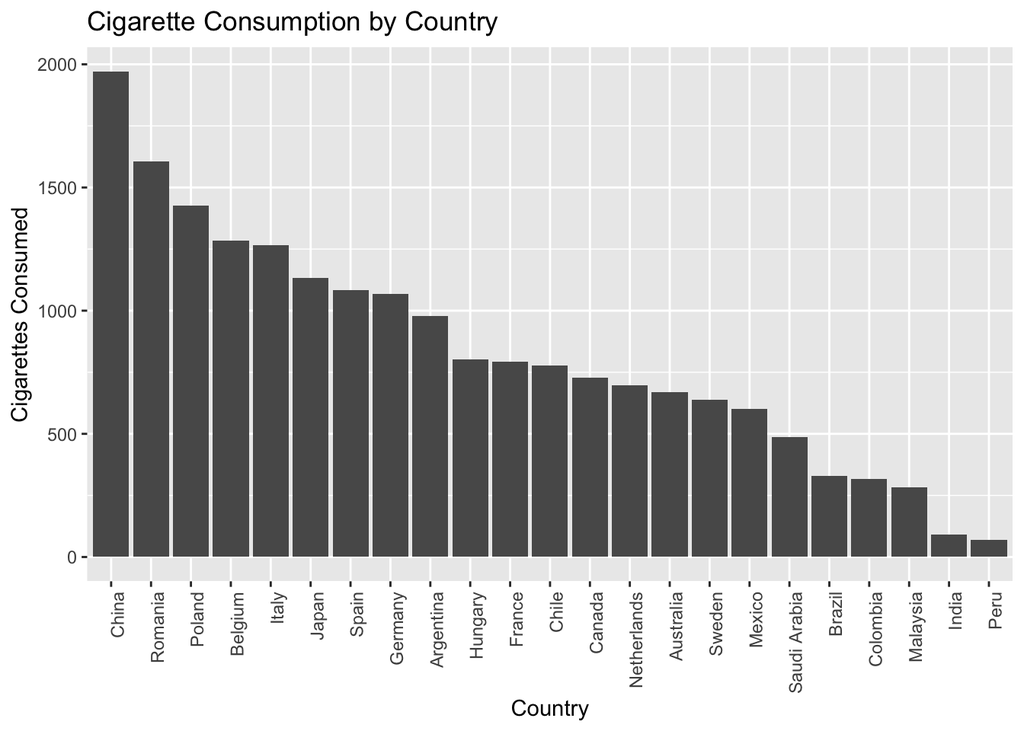

```r
avg_daily_cigar_chart
```

### [Ipsos Global Advisor](https://www.ipsos.com/en/about-us)

Global Views on Exercise and Team Sports

For the exercise information I will use the dataset available [here.](https://www.ipsos.com/sites/default/files/ct/news/documents/2021-08/Global-Views-on-Sports-and-Exercise-Ipsos.pdf)

Fields

1. Country
2. Mean Number of Hours Physical Excercise Per Week

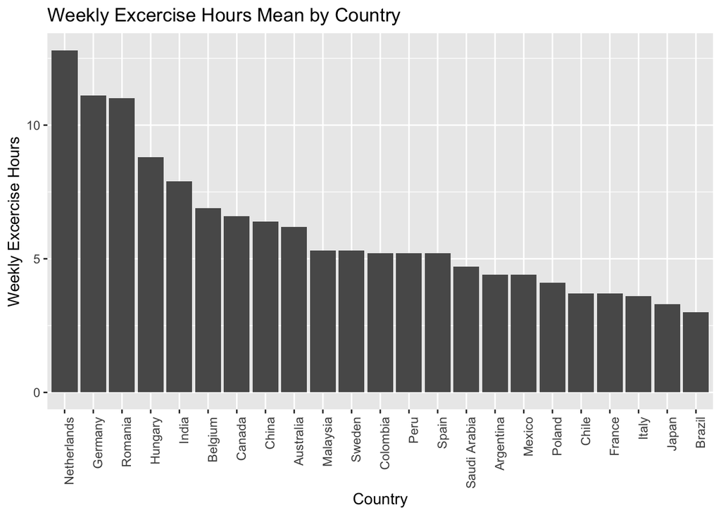

```r
weekly_excercise_chart
```

### [United Nations](https://www.un.org/en/desa/about-us)

Department of Economic and Social Affairs, World Population Prospects 2022

For the age information I will use the dataset available [here.](https://population.un.org/wpp/Download/Standard/CSV/)

Fields

1. Country
2. Median Age

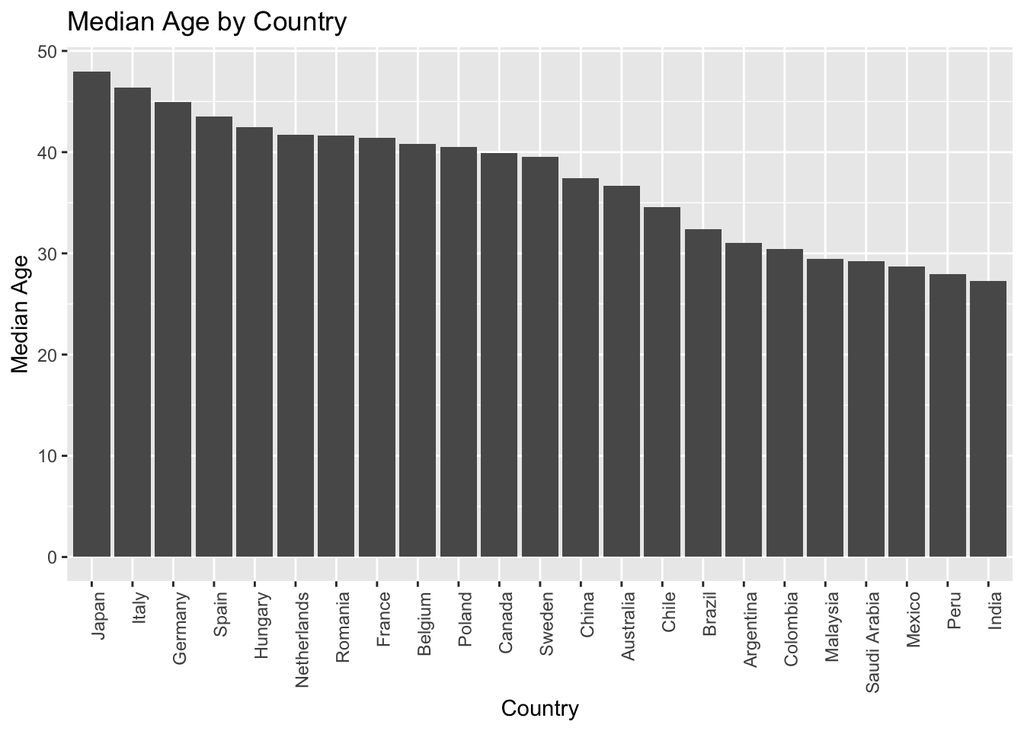

```r
median_age_chart
```

## Table Joins

Now that we have the data loaded, let’s join all of the different tables by country and year

```r
paged_table(covid_stats, options = list(rows.print = 15, cols.print = 10))
```

| country | year | cases | cases_K | cases_M | deaths | deaths_K | deaths_M | mortality_K | consumption | weekly_excercise_hours_mean | median_age |
| --- | --- | --- | --- | --- | --- | --- | --- | --- | --- | --- | --- |
| Argentina | 2020 | 1625514 | 1625.514 | 1.625514 | 43245 | 43.245 | 0.043245 | 26.603893 | 978.40390 | 4.4 | 31.0438 |
| Argentina | 2021 | 5654408 | 5654.408 | 5.654408 | 117169 | 117.169 | 0.117169 | 20.721710 | 978.40390 | 4.4 | 31.0438 |
| Argentina | 2022 | 9721718 | 9721.718 | 9.721718 | 130011 | 130.011 | 0.130011 | 13.373254 | 978.40390 | 4.4 | 31.0438 |
| Australia | 2020 | 28425 | 28.425 | 0.028425 | 909 | 0.909 | 0.000909 | 31.978892 | 668.33090 | 6.2 | 36.6594 |
| Australia | 2021 | 425496 | 425.496 | 0.425496 | 2253 | 2.253 | 0.002253 | 5.294997 | 668.33090 | 6.2 | 36.6594 |
| Australia | 2022 | 10490669 | 10490.669 | 10.490669 | 15891 | 15.891 | 0.015891 | 1.514775 | 668.33090 | 6.2 | 36.6594 |
| Belgium | 2020 | 646496 | 646.496 | 0.646496 | 19528 | 19.528 | 0.019528 | 30.205910 | 1283.99300 | 6.9 | 40.7799 |
| Belgium | 2021 | 2105343 | 2105.343 | 2.105343 | 28331 | 28.331 | 0.028331 | 13.456715 | 1283.99300 | 6.9 | 40.7799 |
| Belgium | 2022 | 4624251 | 4624.251 | 4.624251 | 33000 | 33.000 | 0.033000 | 7.136291 | 1283.99300 | 6.9 | 40.7799 |
| Brazil | 2020 | 7681032 | 7681.032 | 7.681032 | 195072 | 195.072 | 0.195072 | 25.396587 | 329.91480 | 3.0 | 32.4154 |

[output cut: 59 more lines]

```r
paged_table(covid_stats, options = list(rows.print = 15, cols.print = 10))
```

## Mortality

Let’s graph the mortality rate before the Vaccine came out (August 2021).

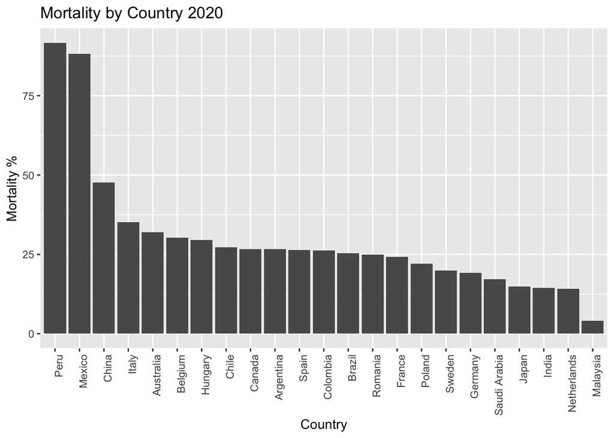

```r
mortality_chart
```